# Target Trial Emulation

Kevin Ying, Peirong Hao, Adam Bress, Tom Greene, Yizhe Xu

2026-03-24

We have explained how to implement TTE through manual coding for an [active-comparator study design](https://uqualitycausal.github.io/TTECausalR/TTEdemoSig.html). In this tutorial, we focus on a placebo-controlled design, where individuals in the control group may meet the eligibility criteria multiple times (Hernán and Robins 2016). This makes it unclear how to define their time zero.

## A Placebo-Controlled Design

We have simulated a dataset as an example to compare the effectiveness of ARB versus no anti-hypertensive medications on reducing the risk of cardiovascular disease (CVD) among subjects with hypertension with no history of chronic disease and no use of ARB medications during the previous 2 years. **Table 1** shows the protocol of the target trial that we wish to run and the emulating plan with observational data side by side.

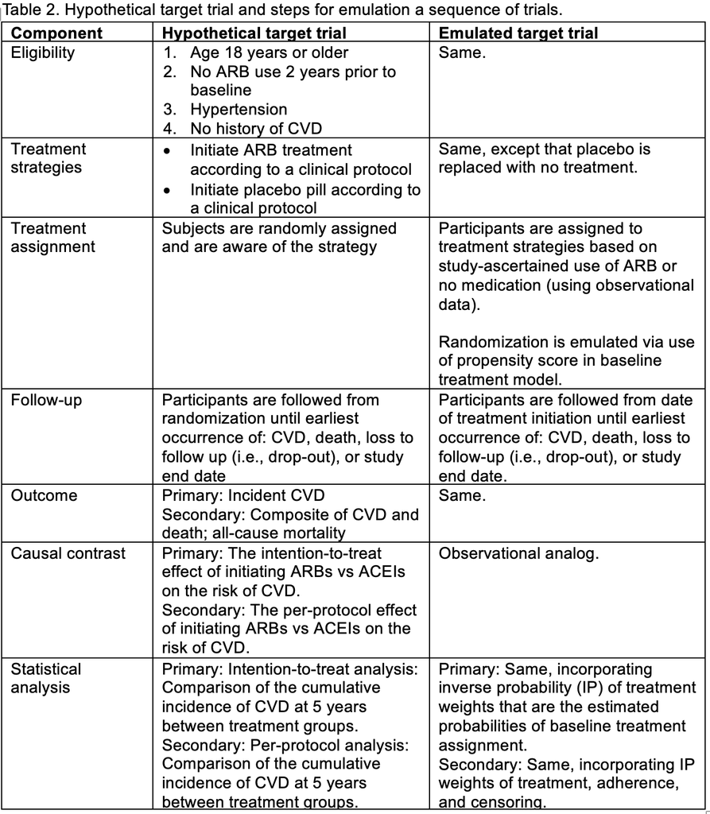

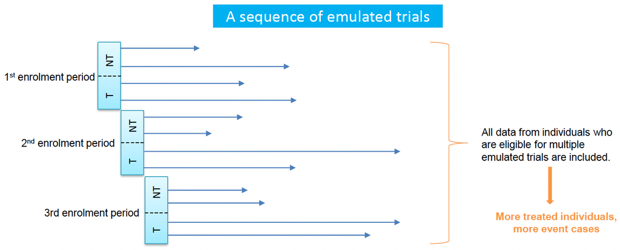

## Example data

We import the data we simulated.

```r
obsdata1 <- readRDS("obsdata1trt.rds")

get_label <- function(x) {
  lbl <- attr(x, "label", exact = TRUE)
  if (is.null(lbl)) "" else as.character(lbl)
}

dict <- data.frame(
  Variable = names(obsdata1),
  Meaning  = vapply(obsdata1, get_label, character(1)),
  check.names = FALSE
)

knitr::kable(dict, caption = "Data Dictionary", row.names = FALSE)
```

Data Dictionary

| Variable | Meaning |
| --- | --- |
| id | Patient ID |
| time | Time index for longitudinal records (months) |
| X1 | Non-ACEI or ARB antihypertensive medication use over time |
| X2 | Standardized systolic blood pressure over time |
| X3 | Biological sex (M=1, F=0) |
| X4 | Standardized diastolic blood pressure at baseline |
| age | Age over time (years) |
| A | Treatment indicator over time (ARB = 1, control = 0 ) |
| Y | Event indicator of cardiovascular disease |
| C | Indicator of early dropout / censoring |

## Emulating a sequence of trials

Suppose treatment and covariates information are updated monthly in our observational data, so we consider each month as a separate enrollment period. For instance, the first enrollment period is Jan. 2017, then Feb. 2017, and so on.

In contrast to emulating a single trial, we need to construct a pooled dataset by stacking the separate data from each trial. Here are a few things to keep in mind during this process:

- Each of the multiple trials has a different baseline (time zero), so the baseline information (covariates and treatment) needs to be set to the values at current time zero if they can vary over time. For instance, the baseline SBP for Trial 1 is the SBP value in Jan. 2017 but the baseline SBP for Trial 2 is the SBP value in Feb. 2017
- The same individual could contribute data to one emulated trial as a non-initiator but as an ARB initiator in another emulated trial later since his/her treatment status changes over time
- As we move the enrollment period forward in calendar time, the follow-up time is decreasing by one month each time since the start of follow-up is one month later, so we need to adjust it across all the emulated trials accordingly
- For the reason above, it is a good practice to prespecify an overall **index window**, say 01/01/2017 - 01/01/2020, and a study period say 01/01/2017 - 01/01/2024, so that even individuals in the last emulated trial are followed up for a sufficient amount of time, i.e., 4 years
- Create an emulated trial indicator for downstream analyses where we can allow treatment effects to remain constant or vary across trials

In the TrialEmulation paper notation, this emulated trial indicator is the trial index $m$. In this tutorial, that variable is `trial_period` after data preparation.

When interpreting marginal treatment effects from a sequence of trials, it is important to state the target trial population. Here we target the pooled population represented by eligible participants across the selected trial periods.

Before starting using the *TrialEmulation* R package, it is crucial to understand the process being carried out in the *data_preparation* function. We explain the steps using a toy example where we only consider three enrollment times: at the beginning of the overall study, month 1, and month 2.

- Patients without hypertension and with CVD are already excluded from our observational data in another pre-processing step
- We apply the rest of eligibility criteria (the first two) in Table 1 to our data and create an “eligible” indicator

```r
obsdata2 <- obsdata1 %>%
  group_by(id) %>%
  mutate(eligible = as.integer(age >= 50 & cumsum(Y) == 0 & (slide_dbl(
    A,
    sum,
    .before = 24, # Look back 24 rows
    .after = -1, # Exclude the current row
    .complete = T
  ) == 0))) %>% # Age over 50, no history of CVD, and no ACEI or ARB treatment in last 24 months.
  mutate(eligible = ifelse(is.na(eligible), 0, eligible)) %>% # if unknown, then not eligible
  ungroup()
```

- Create data for the 1st emulated trial

```r
# Find the first date when some individuals become eligible. This is the start date that we can start enroll subjects
start.date <- obsdata2 %>% filter(eligible == 1) %>% select(time) %>% unique() %>% summarise(start.date = min(time))

# For convenience purpose, convert time to months from this date
obsdata2 <- obsdata2 %>%
  mutate(month = interval(start.date$start.date, time) %/% months(1)) # Month zero is the original study baseline for the 1st trial

# Select eligible individuals
iligible1 <- obsdata2 %>%
  filter(eligible == 1 & month == 0) %>% # Time zero is the original study baseline for the 1st trial
  select(id, A, X1, X2, X3, X4, age) %>%
  rename(assigned_treatment = A, X1_0 = X1, X2_0 = X2, X3_0 = X3, X4_0 = X4, age_0 = age) # Baseline covariates in the 1st trial are the same as the baseline covariates of the study

trial.1 <- obsdata2 %>%
  filter(id %in% iligible1$id & month >= 0) %>% # Month zero is the original study baseline for the 1st trial
  mutate(trial = 0, # Create an emulated trial indicator
    follow_up = month) %>% # No adjustment of follow-up time is needed since the 1st trial share the same baseline as the entire study
  left_join(iligible1)
```

- Create data for the 2nd emulated trial

```r
# Select eligible individuals
iligible2 <- obsdata2 %>%
  filter(eligible == 1 & month == 1) %>%  # Time zero is month 1 for the 2nd trial
  select(id, A, X1, X2, X3, X4, age) %>%
  rename(assigned_treatment = A, X1_0 = X1, X2_0 = X2, X3_0 = X3, X4_0 = X4, age_0 = age) # Baseline covariates in the 2nd trial are the covariates at month 1

trial.2 <- obsdata2 %>%
  filter(id %in% iligible2$id & month >= 1) %>% # Time zero is month 1 for the 2nd trial
  mutate(trial = 1, # Create an emulated trial indicator
    follow_up = month - 1) %>% # Adjust the follow-up time by decreasing by 1
  left_join(iligible2)
```

- Create data for the 3rd emulated trial

```r
# Select eligible individuals
iligible3 <- obsdata2 %>%
  filter(eligible == 1 & month == 2) %>% # Time zero is month 2 for the 3rd trial
  select(id, A, X1, X2, X3, X4, age) %>%
  rename(assigned_treatment = A, X1_0 = X1, X2_0 = X2, X3_0 = X3, X4_0 = X4, age_0 = age) # Baseline covariates in the 3rd trial are the covariates at month 2

trial.3 <- obsdata2 %>%
  filter(id %in% iligible3$id & month >= 2) %>%
  mutate(trial = 2, # Create an emulated trial indicator
    follow_up = month - 2) %>% # Adjust the follow-up time by decreasing by 2
  left_join(iligible3)
```

- Now, we stack all the data from three emulated trials

```r
obsdata2.all.trials <- data.frame(rbind(trial.1, trial.2, trial.3)) %>%
  rename(trial_period = trial,
    followup_time = follow_up,
    treatment = A,
    outcome = Y)
head(obsdata2.all.trials, n = 10)
```

```
#>     id       time X1         X2 X3         X4      age treatment outcome C
#> 1  199 2000-01-01  0  0.4205742  1 -0.5613435 51.04693         0       0 0
#> 2  199 2000-02-01  0  0.3363833  1 -0.5613435 51.13026         0       0 0
#> 3  199 2000-03-01  0  1.3951531  1 -0.5613435 51.21360         0       0 0
#> 4  199 2000-04-01  0  0.8480933  1 -0.5613435 51.29693         0       0 0
#> 5  199 2000-05-01  0  1.1745136  1 -0.5613435 51.38026         0       0 0
#> 6  199 2000-06-01  0  1.2291814  1 -0.5613435 51.46360         0       0 0
#> 7  199 2000-07-01  0  2.1787177  1 -0.5613435 51.54693         0       0 0
#> 8  199 2000-08-01  0 -0.6159137  1 -0.5613435 51.63026         0       0 0
#> 9  199 2000-09-01  0 -0.3460504  1 -0.5613435 51.71360         0       0 0
#> 10 199 2000-10-01  0 -0.6790058  1 -0.5613435 51.79693         0       0 0
#>    eligible month trial_period followup_time assigned_treatment X1_0      X2_0
#> 1         1     0            0             0                  0    0 0.4205742
#> 2         1     1            0             1                  0    0 0.4205742
#> 3         1     2            0             2                  0    0 0.4205742
```

[output cut: 18 more lines]

## Use TrialEmulation R package

We now use the [data_preparation function](https://cran.r-project.org/web/packages/TrialEmulation/TrialEmulation.pdf) to prepare the data for emulating a sequence of trials and focus on the primary intention-to-treat estimand.

```r
prep_ITT_data <- data_preparation(
  data = obsdata2,
  id = "id",
  period = "month",
  treatment = "A",
  outcome = "Y",
  eligible = "eligible", # Indicator of eligibility for the target trial at that visit/period
  estimand_type = "ITT",
  outcome_cov = ~ X1 + X2 + X3 + X4 + age,
  model_var = "assigned_treatment",
  use_censor_weights = F,
  first_period = 0,
  last_period = 2,
  quiet = TRUE,
  control = list(maxit = 100))

dt <- data.frame(prep_ITT_data$data)
dt <- dt %>%
  rename(X1_0 = X1, X2_0 = X2, X3_0 = X3, X4_0 = X4, age_0 = age) %>%
  arrange(trial_period, id, followup_time)
```

```r
paper_map_seq <- tibble::tribble(
  ~Paper_component, ~Code_in_this_tutorial,
  "Sequential trial index m", "trial_period",
  "Expanded pooled trial data", "prep_ITT_data$data",
  "Target trial population", "Eligible participants pooled over first_period to last_period"
)

knitr::kable(paper_map_seq, caption = "Paper-to-Code Mapping (Sequential Trials)", row.names = FALSE)
```

Paper-to-Code Mapping (Sequential Trials)

| Paper_component | Code_in_this_tutorial |
| --- | --- |
| Sequential trial index m | trial_period |
| Expanded pooled trial data | prep_ITT_data$data |
| Target trial population | Eligible participants pooled over first_period to last_period |

Let us compare the data sets prepared on our own and using the *data_preparation* function

```r
table(dt$trial_period == obsdata2.all.trials$trial_period)
```

```
#>
#> TRUE
#> 1168
```

```r
table(dt$id == obsdata2.all.trials$id)
```

```
#>
#> TRUE
#> 1168
```

```r
table(dt$followup_time == obsdata2.all.trials$followup_time)
```

```
#>
#> TRUE
#> 1168
```

```r
table(dt$treatment == obsdata2.all.trials$treatment)
```

```
#>
#> TRUE
#> 1168
```

```r
table(dt$outcome == obsdata2.all.trials$outcome)
```

[output not shown]

```r
table(dt$age_0 == obsdata2.all.trials$age_0)
```

```
#>
#> TRUE
#> 1168
```

```r
table(dt$X1_0 == obsdata2.all.trials$X1_0)
```

```
#>
#> TRUE
#> 1168
```

```r
table(dt$X2_0 == obsdata2.all.trials$X2_0)
```

```
#>
#> TRUE
#> 1168
```

```r
table(dt$X3_0 == obsdata2.all.trials$X3_0)
```

```
#>
#> TRUE
#> 1168
```

```r
table(dt$X4_0 == obsdata2.all.trials$X4_0)
```

```
#>
#> TRUE
#> 1168
```

## Funding

The research reported in this publication was supported in part by the National Center for Advancing Translational Sciences of the National Institutes of Health under Award Number UM1 TR 004409. The content is solely the responsibility of the authors and does not necessarily represent the official views of the National Institutes of Health.

## References

Danaei, Goodarz, Luis A García Rodríguez, Oscar Fernández Cantero, Roger Logan, and Miguel A Hernán. 2013. “Observational Data for Comparative Effectiveness Research: An Emulation of Randomised Trials of Statins and Primary Prevention of Coronary Heart Disease.” *Statistical Methods in Medical Research* 22 (February): 70–96. https://doi.org/10.1177/0962280211403603.

Hernán, Miguel A, and James M Robins. 2016. “Using Big Data to Emulate a Target Trial When a Randomized Trial Is Not Available.” *American Journal of Epidemiology* 183: 758–64.